# Harring project

Artur Mielniczek

```r
Sys.Date()
```

2018-05-25

# Spis treści

1. Streszczenie
2. Biblioteki
3. Importowanie danych oraz ich podgląd
4. Podstawowe statystyki
5. Rozkład danych
6. Zastępowanie wartości pustych
7. Korelacja
8. Model regresji

## Streszczenie

Zadaniem niniejszej analizy jest znalezienie odpowiedzi na pytanie, dlaczego długość śledzia oceanicznego w pewnym okresie zaczęła się zmniejszać. Zbiór danych udąstępniony w ramach badaniach zawierał 52 tysiące obserwacji z połowów. W ramach każdej obserwacji zebrano dane określające dostępność planktonu, warunki środowiskowe, eksploatacje łowisk, oraz miesiąc połowu. W ramach połowu jednej jednostki losowo wybierano od 50 do 100 sztuk trzyletnich śledzi.

W pierwszej części raportu zaimportowano dane i przedstawiono podstawowe statystki wszystkich cech. Następnie przeprowadzono analizę wartości pustych oraz uzupełniono je za pomocą średnich ruchomych. Po wstępnym przetworzeniu danych dokonano analizy korelacji między długoscią śledzią a pozostałymi argumentami. Najbardziej istotny wpływ na wielkość śledzia ma temperatura pod powierzchnią wody. Kolejno przedstawiono wykres zmiany wielkości śledzia w czasie, gdzie został wyznaczony moment, w którym jego wielkośc zaczęła ulegać zmniejszeniu.

## Biblioteki

```r
install.packages("gdata")
install.packages("dplyr")
install.packages("ggplot2")
install.packages("gridExtra")
install.packages("imputeTS")
install.packages("mice")
install.packages("VIM")
install.packages("corrplot")
install.packages("plotly")
install.packages("shiny")
install.packages("caret")
library(caret)
library(shiny)
library(corrplot)
library(plotly)
library(VIM)
library(mice)
library(imputeTS)
library(dplyr)
library(ggplot2)
library(gridExtra)
```

## Importowanie danych oraz ich podgląd

1. length: długość złowionego śledzia [cm]
2. cfin1: dostępność planktonu [zagęszczenie Calanus finmarchicus gat. 1]
3. cfin2: dostępność planktonu [zagęszczenie Calanus finmarchicus gat. 2]
4. chel1: dostępność planktonu [zagęszczenie Calanus helgolandicus gat. 1]
5. chel2: dostępność planktonu [zagęszczenie Calanus helgolandicus gat. 2]
6. lcop1: dostępność planktonu [zagęszczenie Widłonogów gat. 1]
7. lcop2: dostępność planktonu [zagęszczenie Widłonogów gat. 2]
8. fbar: natężenie połowów w regionie [ułamek pozostawionego narybku]
9. recr: roczny narybek [liczba śledzi]
10. cumf: łączne roczne natężenie połowów w regionie [ułamek pozostawionego narybku]
11. totaln: łączna liczba ryb złowionych w ramach połowu [liczba śledzi]
12. sst: temperatura przy powierzchni wody [°C]
13. sal: poziom zasolenia wody [Knudsen ppt]
14. xmonth: miesiąc połowu [numer miesiąca]
15. nao: oscylacja północnoatlantycka [mb]

```r
# przypisanie danych do zmiennej
fish_data <- read.csv(url("http://www.cs.put.poznan.pl/dbrzezinski/teaching/sphd/sledzie.csv"),
header = TRUE, sep = ",", na.strings = "?")
fish_data <- fish_data %>% rename(lp = X)
```

```r
head(fish_data, nrow= 5)
```

| lp | length | cfin1 | cfin2 | chel1 | chel2 | lcop1 | lcop2 | fbar | recr | cumf | totaln | sst | sal | xmonth | nao |
| --- | --- | --- | --- | --- | --- | --- | --- | --- | --- | --- | --- | --- | --- | --- | --- |
| 0 | 23.0 | 0.02778 | 0.27785 | 2.46875 | NA | 2.54787 | 26.35881 | 0.356 | 482831 | 0.3059879 | 267380.8 | 14.30693 | 35.51234 | 7 | 2.8 |
| 1 | 22.5 | 0.02778 | 0.27785 | 2.46875 | 21.43548 | 2.54787 | 26.35881 | 0.356 | 482831 | 0.3059879 | 267380.8 | 14.30693 | 35.51234 | 7 | 2.8 |
| 2 | 25.0 | 0.02778 | 0.27785 | 2.46875 | 21.43548 | 2.54787 | 26.35881 | 0.356 | 482831 | 0.3059879 | 267380.8 | 14.30693 | 35.51234 | 7 | 2.8 |
| 3 | 25.5 | 0.02778 | 0.27785 | 2.46875 | 21.43548 | 2.54787 | 26.35881 | 0.356 | 482831 | 0.3059879 | 267380.8 | 14.30693 | 35.51234 | 7 | 2.8 |
| 4 | 24.0 | 0.02778 | 0.27785 | 2.46875 | 21.43548 | 2.54787 | 26.35881 | 0.356 | 482831 | 0.3059879 | 267380.8 | 14.30693 | 35.51234 | 7 | 2.8 |
| 5 | 22.0 | 0.02778 | 0.27785 | 2.46875 | 21.43548 | 2.54787 | NA | 0.356 | 482831 | 0.3059879 | 267380.8 | 14.30693 | 35.51234 | 7 | 2.8 |

## Podstawowe statystyki

```r
sprintf("Liczba wierszy razem z wartościami pustymi %d", nrow(fish_data))
```

'Liczba wierszy razem z wartosciami pustymi 52582'

```r
sprintf("Liczba wierszy bez pustych wierszy %d", nrow(na.omit(fish_data)))
```

'Liczba wierszy bez pustych wierszy 42488'

```r
sprintf("Liczba kolumn %d", ncol(fish_data))
```

'Liczba kolumn 16'

```r
summary(fish_data)
```

```
       lp            length         cfin1             cfin2
 Min.   :    0   Min.   :19.0   Min.   : 0.0000   Min.   : 0.0000
 1st Qu.:13145   1st Qu.:24.0   1st Qu.: 0.0000   1st Qu.: 0.2778
 Median :26291   Median :25.5   Median : 0.1111   Median : 0.7012
 Mean   :26291   Mean   :25.3   Mean   : 0.4458   Mean   : 2.0248
 3rd Qu.:39436   3rd Qu.:26.5   3rd Qu.: 0.3333   3rd Qu.: 1.7936
 Max.   :52581   Max.   :32.5   Max.   :37.6667   Max.   :19.3958
                                NA's   :1581      NA's   :1536
     chel1            chel2            lcop1              lcop2
 Min.   : 0.000   Min.   : 5.238   Min.   :  0.3074   Min.   : 7.849
 1st Qu.: 2.469   1st Qu.:13.427   1st Qu.:  2.5479   1st Qu.:17.808
 Median : 5.750   Median :21.673   Median :  7.0000   Median :24.859
 Mean   :10.006   Mean   :21.221   Mean   : 12.8108   Mean   :28.419
 3rd Qu.:11.500   3rd Qu.:27.193   3rd Qu.: 21.2315   3rd Qu.:37.232
 Max.   :75.000   Max.   :57.706   Max.   :115.5833   Max.   :68.736
 NA's   :1555     NA's   :1556     NA's   :1653       NA's   :1591
      fbar             recr              cumf             totaln
 Min.   :0.0680   Min.   : 140515   Min.   :0.06833   Min.   : 144137
 1st Qu.:0.2270   1st Qu.: 360061   1st Qu.:0.14809   1st Qu.: 306068
 Median :0.3320   Median : 421391   Median :0.23191   Median : 539558
 Mean   :0.3304   Mean   : 520367   Mean   :0.22981   Mean   : 514973
 3rd Qu.:0.4560   3rd Qu.: 724151   3rd Qu.:0.29803   3rd Qu.: 730351
 Max.   :0.8490   Max.   :1565890   Max.   :0.39801   Max.   :1015595

      sst             sal            xmonth            nao
 Min.   :12.77   Min.   :35.40   Min.   : 1.000   Min.   :-4.89000
 1st Qu.:13.60   1st Qu.:35.51   1st Qu.: 5.000   1st Qu.:-1.89000
 Median :13.86   Median :35.51   Median : 8.000   Median : 0.20000
 Mean   :13.87   Mean   :35.51   Mean   : 7.258   Mean   :-0.09236
 3rd Qu.:14.16   3rd Qu.:35.52   3rd Qu.: 9.000   3rd Qu.: 1.63000
 Max.   :14.73   Max.   :35.61   Max.   :12.000   Max.   : 5.08000
 NA's   :1584
```

## Rozkład danych

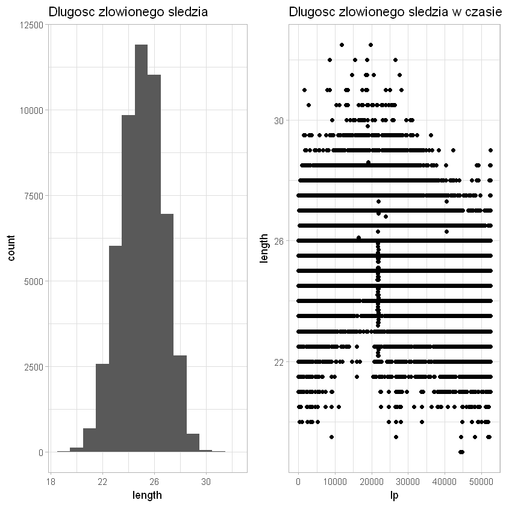

```r
c_1 <- ggplot(fish_data, aes(length)) + geom_histogram(binwidth = 1) +
  theme_light() + ggtitle('Długość złowionego śledzia')
c_2 <- ggplot(fish_data, aes(x=lp,y=length)) + geom_point() + theme_light() +
ggtitle('Długość złowionego śledzia w czasie')

grid.arrange(c_1,c_2, nrow=1)
```

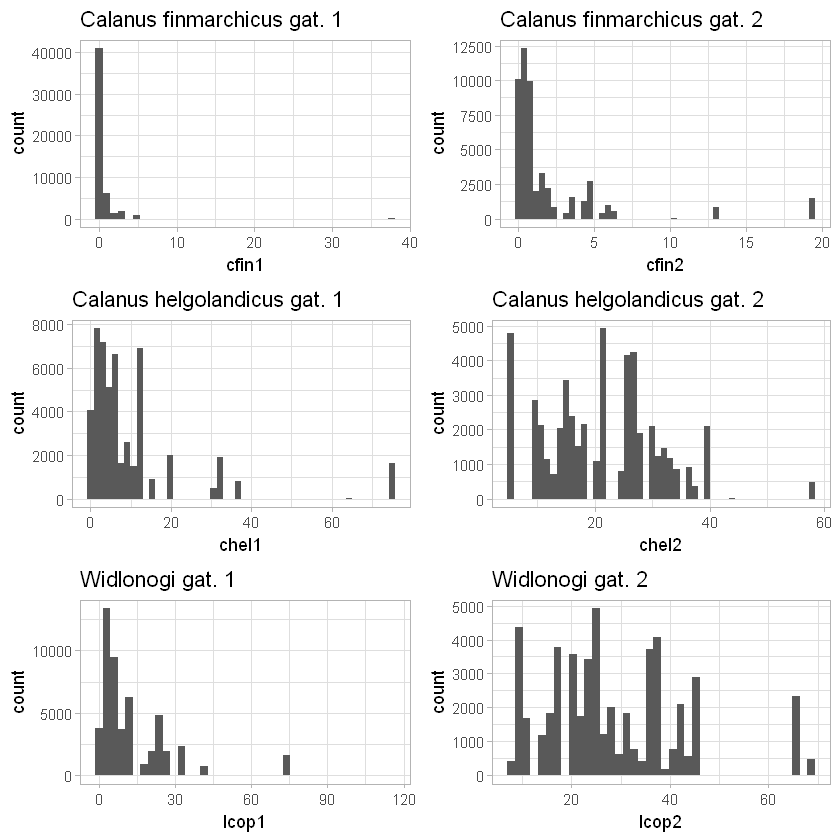

```r
p_cfin1 <- ggplot(fish_data, aes(cfin1)) + geom_histogram(bins = 40) +
  theme_light() + ggtitle('Calanus finmarchicus gat. 1')
p_cfin2 <- ggplot(fish_data, aes(cfin2)) + geom_histogram(bins = 50) +
  theme_light() + ggtitle('Calanus finmarchicus gat. 2')
p_chel1 <- ggplot(fish_data, aes(chel1)) + geom_histogram(bins = 50) +
  theme_light() + ggtitle('Calanus helgolandicus gat. 1')
p_chel2 <- ggplot(fish_data, aes(chel2)) + geom_histogram(bins = 50) +
  theme_light() + ggtitle('Calanus helgolandicus gat. 2')
p_lcop1 <- ggplot(fish_data, aes(lcop1)) + geom_histogram(bins = 40) +
  theme_light() + ggtitle('Widłonogi gat. 1')
p_lcop2 <- ggplot(fish_data, aes(lcop2)) + geom_histogram(bins = 40) +
  theme_light()+ ggtitle('Widłonogi gat. 2')
grid.arrange(p_cfin1, p_cfin2,p_chel1,p_chel2,p_lcop1,p_lcop2, nrow=3)
#częstotliwość wystepowania zjawiska
```

[output not shown]

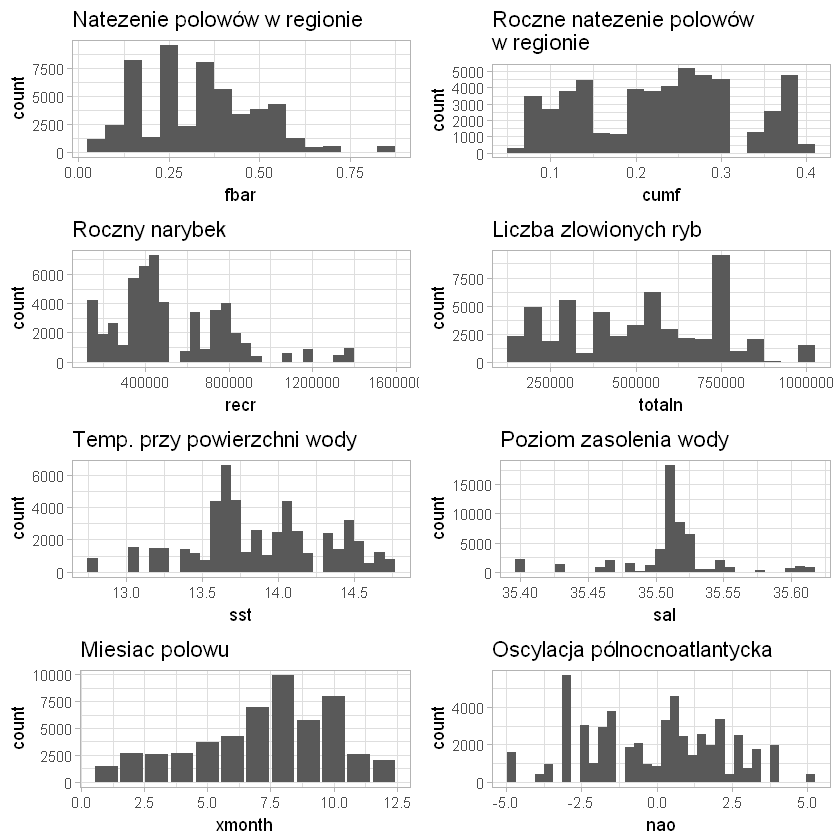

```r
p_fbar <- ggplot(fish_data, aes(fbar)) + geom_histogram(binwidth = 0.05) +
  theme_light() + ggtitle('Natężenie połowów w regionie')
p_cumf <- ggplot(fish_data, aes(cumf)) + geom_histogram(binwidth = 0.02) +
  theme_light() + ggtitle('Roczne natężenie połowów\nw regionie')
p_recr <- ggplot(fish_data, aes(recr)) + geom_histogram() +
  theme_light() + ggtitle('Roczny narybek')
p_totaln <- ggplot(fish_data, aes(totaln)) + geom_histogram(binwidth = 50000) +
  theme_light() + ggtitle('Liczba złowionych ryb')
p_sst <- ggplot(fish_data, aes(sst)) + geom_histogram() +
  theme_light() + ggtitle('Temp. przy powierzchni wody')
p_sal <- ggplot(fish_data, aes(sal)) + geom_histogram() +
  theme_light() + ggtitle('Poziom zasolenia wody')
p_xmonth <- ggplot(fish_data, aes(xmonth)) + geom_bar(stat = 'count') +
  theme_light() + ggtitle('Miesiąc połowu')
p_nao <- ggplot(fish_data, aes(nao)) + geom_histogram(binwidth = 0.3) +
  theme_light() + ggtitle('Oscylacja północnoatlantycka')
grid.arrange(p_fbar, p_cumf, p_recr, p_totaln,p_sst,p_sal,p_xmonth,p_nao, nrow=4)
```

## Zastępowanie wartości pustych

```r
#kolumny zawierające wartości puste
colnames(fish_data)[apply(is.na(fish_data), 2, any)]
```

1. 'cfin1'

2. 'cfin2'

3. 'chel1'

4. 'chel2'

5. 'lcop1'

6. 'lcop2'

7. 'sst'

```r
md.pattern(fish_data)
```

|  | lp | length | fbar | recr | cumf | totaln | sal | xmonth | nao | cfin2 | chel1 | chel2 | cfin1 | sst | lcop2 | lcop1 |  |
| --- | --- | --- | --- | --- | --- | --- | --- | --- | --- | --- | --- | --- | --- | --- | --- | --- | --- |
| 42488 | 1 | 1 | 1 | 1 | 1 | 1 | 1 | 1 | 1 | 1 | 1 | 1 | 1 | 1 | 1 | 1 | 0 |
| 1308 | 1 | 1 | 1 | 1 | 1 | 1 | 1 | 1 | 1 | 1 | 1 | 1 | 0 | 1 | 1 | 1 | 1 |
| 1260 | 1 | 1 | 1 | 1 | 1 | 1 | 1 | 1 | 1 | 0 | 1 | 1 | 1 | 1 | 1 | 1 | 1 |
| 1315 | 1 | 1 | 1 | 1 | 1 | 1 | 1 | 1 | 1 | 1 | 0 | 1 | 1 | 1 | 1 | 1 | 1 |
| 1286 | 1 | 1 | 1 | 1 | 1 | 1 | 1 | 1 | 1 | 1 | 1 | 0 | 1 | 1 | 1 | 1 | 1 |
| 1386 | 1 | 1 | 1 | 1 | 1 | 1 | 1 | 1 | 1 | 1 | 1 | 1 | 1 | 1 | 1 | 0 | 1 |
| 1312 | 1 | 1 | 1 | 1 | 1 | 1 | 1 | 1 | 1 | 1 | 1 | 1 | 1 | 1 | 0 | 1 | 1 |
| 1314 | 1 | 1 | 1 | 1 | 1 | 1 | 1 | 1 | 1 | 1 | 1 | 1 | 1 | 0 | 1 | 1 | 1 |
| 45 | 1 | 1 | 1 | 1 | 1 | 1 | 1 | 1 | 1 | 0 | 1 | 1 | 0 | 1 | 1 | 1 | 2 |
| 41 | 1 | 1 | 1 | 1 | 1 | 1 | 1 | 1 | 1 | 1 | 0 | 1 | 0 | 1 | 1 | 1 | 2 |
| 29 | 1 | 1 | 1 | 1 | 1 | 1 | 1 | 1 | 1 | 0 | 0 | 1 | 1 | 1 | 1 | 1 | 2 |
| 40 | 1 | 1 | 1 | 1 | 1 | 1 | 1 | 1 | 1 | 1 | 1 | 0 | 0 | 1 | 1 | 1 | 2 |
| 47 | 1 | 1 | 1 | 1 | 1 | 1 | 1 | 1 | 1 | 0 | 1 | 0 | 1 | 1 | 1 | 1 | 2 |
| 34 | 1 | 1 | 1 | 1 | 1 | 1 | 1 | 1 | 1 | 1 | 0 | 0 | 1 | 1 | 1 | 1 | 2 |
| 41 | 1 | 1 | 1 | 1 | 1 | 1 | 1 | 1 | 1 | 1 | 1 | 1 | 0 | 1 | 1 | 0 | 2 |
| 40 | 1 | 1 | 1 | 1 | 1 | 1 | 1 | 1 | 1 | 0 | 1 | 1 | 1 | 1 | 1 | 0 | 2 |
| 39 | 1 | 1 | 1 | 1 | 1 | 1 | 1 | 1 | 1 | 1 | 0 | 1 | 1 | 1 | 1 | 0 | 2 |
| 43 | 1 | 1 | 1 | 1 | 1 | 1 | 1 | 1 | 1 | 1 | 1 | 0 | 1 | 1 | 1 | 0 | 2 |
| 47 | 1 | 1 | 1 | 1 | 1 | 1 | 1 | 1 | 1 | 1 | 1 | 1 | 0 | 1 | 0 | 1 | 2 |
| 41 | 1 | 1 | 1 | 1 | 1 | 1 | 1 | 1 | 1 | 0 | 1 | 1 | 1 | 1 | 0 | 1 | 2 |
| 45 | 1 | 1 | 1 | 1 | 1 | 1 | 1 | 1 | 1 | 1 | 0 | 1 | 1 | 1 | 0 | 1 | 2 |
| 43 | 1 | 1 | 1 | 1 | 1 | 1 | 1 | 1 | 1 | 1 | 1 | 0 | 1 | 1 | 0 | 1 | 2 |
| 41 | 1 | 1 | 1 | 1 | 1 | 1 | 1 | 1 | 1 | 1 | 1 | 1 | 1 | 1 | 0 | 0 | 2 |
| 42 | 1 | 1 | 1 | 1 | 1 | 1 | 1 | 1 | 1 | 1 | 1 | 1 | 0 | 0 | 1 | 1 | 2 |
| 49 | 1 | 1 | 1 | 1 | 1 | 1 | 1 | 1 | 1 | 0 | 1 | 1 | 1 | 0 | 1 | 1 | 2 |
| 33 | 1 | 1 | 1 | 1 | 1 | 1 | 1 | 1 | 1 | 1 | 0 | 1 | 1 | 0 | 1 | 1 | 2 |
| 38 | 1 | 1 | 1 | 1 | 1 | 1 | 1 | 1 | 1 | 1 | 1 | 0 | 1 | 0 | 1 | 1 | 2 |
| 46 | 1 | 1 | 1 | 1 | 1 | 1 | 1 | 1 | 1 | 1 | 1 | 1 | 1 | 0 | 1 | 0 | 2 |
| 40 | 1 | 1 | 1 | 1 | 1 | 1 | 1 | 1 | 1 | 1 | 1 | 1 | 1 | 0 | 0 | 1 | 2 |
| 3 | 1 | 1 | 1 | 1 | 1 | 1 | 1 | 1 | 1 | 0 | 0 | 1 | 0 | 1 | 1 | 1 | 3 |
| 1 | 1 | 1 | 1 | 1 | 1 | 1 | 1 | 1 | 1 | 0 | 1 | 0 | 0 | 1 | 1 | 1 | 3 |
| 2 | 1 | 1 | 1 | 1 | 1 | 1 | 1 | 1 | 1 | 0 | 0 | 0 | 1 | 1 | 1 | 1 | 3 |
| 2 | 1 | 1 | 1 | 1 | 1 | 1 | 1 | 1 | 1 | 0 | 0 | 1 | 1 | 1 | 1 | 0 | 3 |
| 1 | 1 | 1 | 1 | 1 | 1 | 1 | 1 | 1 | 1 | 1 | 1 | 0 | 0 | 1 | 1 | 0 | 3 |
| 1 | 1 | 1 | 1 | 1 | 1 | 1 | 1 | 1 | 1 | 0 | 1 | 0 | 1 | 1 | 1 | 0 | 3 |
| 2 | 1 | 1 | 1 | 1 | 1 | 1 | 1 | 1 | 1 | 1 | 0 | 0 | 1 | 1 | 1 | 0 | 3 |
| 4 | 1 | 1 | 1 | 1 | 1 | 1 | 1 | 1 | 1 | 0 | 1 | 1 | 0 | 1 | 0 | 1 | 3 |
| 1 | 1 | 1 | 1 | 1 | 1 | 1 | 1 | 1 | 1 | 1 | 0 | 1 | 0 | 1 | 0 | 1 | 3 |
| 2 | 1 | 1 | 1 | 1 | 1 | 1 | 1 | 1 | 1 | 0 | 0 | 1 | 1 | 1 | 0 | 1 | 3 |
| 4 | 1 | 1 | 1 | 1 | 1 | 1 | 1 | 1 | 1 | 1 | 1 | 0 | 0 | 1 | 0 | 1 | 3 |
| 1 | 1 | 1 | 1 | 1 | 1 | 1 | 1 | 1 | 1 | 0 | 1 | 0 | 1 | 1 | 0 | 1 | 3 |
| 1 | 1 | 1 | 1 | 1 | 1 | 1 | 1 | 1 | 1 | 1 | 0 | 0 | 1 | 1 | 0 | 1 | 3 |
| 2 | 1 | 1 | 1 | 1 | 1 | 1 | 1 | 1 | 1 | 1 | 1 | 0 | 1 | 1 | 0 | 0 | 3 |
| 1 | 1 | 1 | 1 | 1 | 1 | 1 | 1 | 1 | 1 | 1 | 0 | 1 | 0 | 0 | 1 | 1 | 3 |
| 3 | 1 | 1 | 1 | 1 | 1 | 1 | 1 | 1 | 1 | 0 | 0 | 1 | 1 | 0 | 1 | 1 | 3 |
| 1 | 1 | 1 | 1 | 1 | 1 | 1 | 1 | 1 | 1 | 1 | 1 | 0 | 0 | 0 | 1 | 1 | 3 |
| 4 | 1 | 1 | 1 | 1 | 1 | 1 | 1 | 1 | 1 | 0 | 1 | 0 | 1 | 0 | 1 | 1 | 3 |
| 1 | 1 | 1 | 1 | 1 | 1 | 1 | 1 | 1 | 1 | 1 | 1 | 1 | 0 | 0 | 1 | 0 | 3 |
| 1 | 1 | 1 | 1 | 1 | 1 | 1 | 1 | 1 | 1 | 0 | 1 | 1 | 1 | 0 | 1 | 0 | 3 |
| 2 | 1 | 1 | 1 | 1 | 1 | 1 | 1 | 1 | 1 | 1 | 0 | 1 | 1 | 0 | 1 | 0 | 3 |
| 2 | 1 | 1 | 1 | 1 | 1 | 1 | 1 | 1 | 1 | 1 | 1 | 0 | 1 | 0 | 1 | 0 | 3 |
| 1 | 1 | 1 | 1 | 1 | 1 | 1 | 1 | 1 | 1 | 0 | 1 | 1 | 1 | 0 | 0 | 1 | 3 |
| 3 | 1 | 1 | 1 | 1 | 1 | 1 | 1 | 1 | 1 | 1 | 1 | 0 | 1 | 0 | 0 | 1 | 3 |
| 3 | 1 | 1 | 1 | 1 | 1 | 1 | 1 | 1 | 1 | 1 | 1 | 1 | 1 | 0 | 0 | 0 | 3 |
|  | 0 | 0 | 0 | 0 | 0 | 0 | 0 | 0 | 0 | 1536 | 1555 | 1556 | 1581 | 1584 | 1591 | 1653 | 11056 |

```r
#cfin1
statsNA(fish_data$cfin1, bins = 5)
```

```
[1] "Length of time series:"
[1] 52582
[1] "-------------------------"
[1] "Number of Missing Values:"
[1] 1581
[1] "-------------------------"
[1] "Percentage of Missing Values:"
[1] "3.01%"
[1] "-------------------------"
[1] "Stats for Bins"
[1] "  Bin 1 (10517 values from 1 to 10517) :      303 NAs (2.88%)"
[1] "  Bin 2 (10517 values from 10518 to 21034) :      340 NAs (3.23%)"
[1] "  Bin 3 (10517 values from 21035 to 31551) :      294 NAs (2.8%)"
[1] "  Bin 4 (10517 values from 31552 to 42068) :      331 NAs (3.15%)"
[1] "  Bin 5 (10514 values from 42069 to 52582) :      313 NAs (2.98%)"
[1] "-------------------------"
[1] "Longest NA gap (series of consecutive NAs)"
[1] "3 in a row"
[1] "-------------------------"
[1] "Most frequent gap size (series of consecutive NA series)"
[1] "1 NA in a row (occuring 1480 times)"
[1] "-------------------------"
[1] "Gap size accounting for most NAs"
[1] "1 NA in a row (occuring 1480 times, making up for overall 1480 NAs)"
[1] "-------------------------"
[1] "Overview NA series"
[1] "  1 NA in a row: 1480 times"
[1] "  2 NA in a row: 49 times"
[1] "  3 NA in a row: 1 times"
```

```r
#cfin2
statsNA(fish_data$cfin2, bins = 5)
```

```
[1] "Length of time series:"
[1] 52582
[1] "-------------------------"
[1] "Number of Missing Values:"
[1] 1536
[1] "-------------------------"
[1] "Percentage of Missing Values:"
[1] "2.92%"
[1] "-------------------------"
[1] "Stats for Bins"
[1] "  Bin 1 (10517 values from 1 to 10517) :      312 NAs (2.97%)"
[1] "  Bin 2 (10517 values from 10518 to 21034) :      291 NAs (2.77%)"
[1] "  Bin 3 (10517 values from 21035 to 31551) :      302 NAs (2.87%)"
[1] "  Bin 4 (10517 values from 31552 to 42068) :      321 NAs (3.05%)"
[1] "  Bin 5 (10514 values from 42069 to 52582) :      310 NAs (2.95%)"
[1] "-------------------------"
[1] "Longest NA gap (series of consecutive NAs)"
[1] "3 in a row"
[1] "-------------------------"
[1] "Most frequent gap size (series of consecutive NA series)"
[1] "1 NA in a row (occuring 1461 times)"
[1] "-------------------------"
[1] "Gap size accounting for most NAs"
[1] "1 NA in a row (occuring 1461 times, making up for overall 1461 NAs)"
[1] "-------------------------"
[1] "Overview NA series"
[1] "  1 NA in a row: 1461 times"
[1] "  2 NA in a row: 36 times"
[1] "  3 NA in a row: 1 times"
```

```r
#chel1
statsNA(fish_data$chel1, bins = 5)
```

```
[1] "Length of time series:"
[1] 52582
[1] "-------------------------"
[1] "Number of Missing Values:"
[1] 1555
[1] "-------------------------"
[1] "Percentage of Missing Values:"
[1] "2.96%"
[1] "-------------------------"
[1] "Stats for Bins"
[1] "  Bin 1 (10517 values from 1 to 10517) :      296 NAs (2.81%)"
[1] "  Bin 2 (10517 values from 10518 to 21034) :      341 NAs (3.24%)"
[1] "  Bin 3 (10517 values from 21035 to 31551) :      293 NAs (2.79%)"
[1] "  Bin 4 (10517 values from 31552 to 42068) :      316 NAs (3%)"
[1] "  Bin 5 (10514 values from 42069 to 52582) :      309 NAs (2.94%)"
[1] "-------------------------"
[1] "Longest NA gap (series of consecutive NAs)"
[1] "3 in a row"
[1] "-------------------------"
[1] "Most frequent gap size (series of consecutive NA series)"
[1] "1 NA in a row (occuring 1471 times)"
[1] "-------------------------"
[1] "Gap size accounting for most NAs"
[1] "1 NA in a row (occuring 1471 times, making up for overall 1471 NAs)"
[1] "-------------------------"
[1] "Overview NA series"
[1] "  1 NA in a row: 1471 times"
[1] "  2 NA in a row: 39 times"
[1] "  3 NA in a row: 2 times"
```

```r
#lcop1
statsNA(fish_data$lcop1, bins = 5)
```

```
[1] "Length of time series:"
[1] 52582
[1] "-------------------------"
[1] "Number of Missing Values:"
[1] 1653
[1] "-------------------------"
[1] "Percentage of Missing Values:"
[1] "3.14%"
[1] "-------------------------"
[1] "Stats for Bins"
[1] "  Bin 1 (10517 values from 1 to 10517) :      366 NAs (3.48%)"
[1] "  Bin 2 (10517 values from 10518 to 21034) :      292 NAs (2.78%)"
[1] "  Bin 3 (10517 values from 21035 to 31551) :      337 NAs (3.2%)"
[1] "  Bin 4 (10517 values from 31552 to 42068) :      312 NAs (2.97%)"
[1] "  Bin 5 (10514 values from 42069 to 52582) :      346 NAs (3.29%)"
[1] "-------------------------"
[1] "Longest NA gap (series of consecutive NAs)"
[1] "2 in a row"
[1] "-------------------------"
[1] "Most frequent gap size (series of consecutive NA series)"
[1] "1 NA in a row (occuring 1551 times)"
[1] "-------------------------"
[1] "Gap size accounting for most NAs"
[1] "1 NA in a row (occuring 1551 times, making up for overall 1551 NAs)"
[1] "-------------------------"
[1] "Overview NA series"
[1] "  1 NA in a row: 1551 times"
[1] "  2 NA in a row: 51 times"
```

```r
#lcop2
statsNA(fish_data$lcop2, bins = 5)
```

```
[1] "Length of time series:"
[1] 52582
[1] "-------------------------"
[1] "Number of Missing Values:"
[1] 1591
[1] "-------------------------"
[1] "Percentage of Missing Values:"
[1] "3.03%"
[1] "-------------------------"
[1] "Stats for Bins"
[1] "  Bin 1 (10517 values from 1 to 10517) :      319 NAs (3.03%)"
[1] "  Bin 2 (10517 values from 10518 to 21034) :      343 NAs (3.26%)"
[1] "  Bin 3 (10517 values from 21035 to 31551) :      298 NAs (2.83%)"
[1] "  Bin 4 (10517 values from 31552 to 42068) :      302 NAs (2.87%)"
[1] "  Bin 5 (10514 values from 42069 to 52582) :      329 NAs (3.13%)"
[1] "-------------------------"
[1] "Longest NA gap (series of consecutive NAs)"
[1] "3 in a row"
[1] "-------------------------"
[1] "Most frequent gap size (series of consecutive NA series)"
[1] "1 NA in a row (occuring 1503 times)"
[1] "-------------------------"
[1] "Gap size accounting for most NAs"
[1] "1 NA in a row (occuring 1503 times, making up for overall 1503 NAs)"
[1] "-------------------------"
[1] "Overview NA series"
[1] "  1 NA in a row: 1503 times"
[1] "  2 NA in a row: 41 times"
[1] "  3 NA in a row: 2 times"
```

```r
#sst
statsNA(fish_data$sst, bins = 5)
```

```
[1] "Length of time series:"
[1] 52582
[1] "-------------------------"
[1] "Number of Missing Values:"
[1] 1584
[1] "-------------------------"
[1] "Percentage of Missing Values:"
[1] "3.01%"
[1] "-------------------------"
[1] "Stats for Bins"
[1] "  Bin 1 (10517 values from 1 to 10517) :      321 NAs (3.05%)"
[1] "  Bin 2 (10517 values from 10518 to 21034) :      313 NAs (2.98%)"
[1] "  Bin 3 (10517 values from 21035 to 31551) :      298 NAs (2.83%)"
[1] "  Bin 4 (10517 values from 31552 to 42068) :      310 NAs (2.95%)"
[1] "  Bin 5 (10514 values from 42069 to 52582) :      342 NAs (3.25%)"
[1] "-------------------------"
[1] "Longest NA gap (series of consecutive NAs)"
[1] "3 in a row"
[1] "-------------------------"
[1] "Most frequent gap size (series of consecutive NA series)"
[1] "1 NA in a row (occuring 1501 times)"
[1] "-------------------------"
[1] "Gap size accounting for most NAs"
[1] "1 NA in a row (occuring 1501 times, making up for overall 1501 NAs)"
[1] "-------------------------"
[1] "Overview NA series"
[1] "  1 NA in a row: 1501 times"
[1] "  2 NA in a row: 40 times"
[1] "  3 NA in a row: 1 times"
```

Dla powyższych pozycji wartośći NA przyjmują maksymalnie 3.14%. Do uzupełnienia wartości pustach można zastosować średnią ruchomą z 4 sąsiadujących pomiarów

```r
fish_data$cfin1 <- na.ma(fish_data$cfin1, k = 4, weighting = "exponential")
fish_data$cfin2 <- na.ma(fish_data$cfin2, k = 4, weighting = "exponential")
fish_data$chel1 <- na.ma(fish_data$chel1, k = 4, weighting = "exponential")
fish_data$chel2 <- na.ma(fish_data$chel2, k = 4, weighting = "exponential")
fish_data$lcop1 <- na.ma(fish_data$lcop1, k = 4, weighting = "exponential")
fish_data$lcop2 <- na.ma(fish_data$lcop2, k = 4, weighting = "exponential")
fish_data$sst   <- na.ma(fish_data$sst, k = 4, weighting = "exponential")
```

## Korelacja

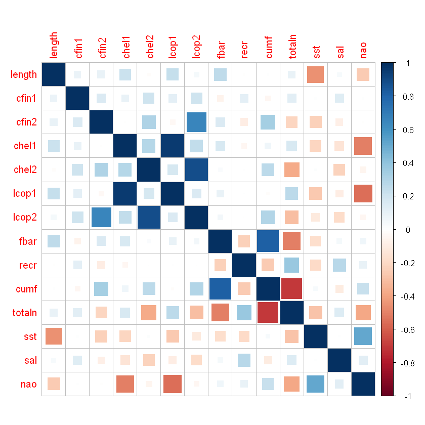

```r
Matrix<-cor(fish_data[,-c(1,15)])
corrplot(Matrix, method="square")
```

Rozmiar śledzia jest silnie zależny od temperatury przy powierchni wody. Ponadto istnieje współzależność między jego rozmiarem dostępnością chel1,lcop1,fbar oraz nao.

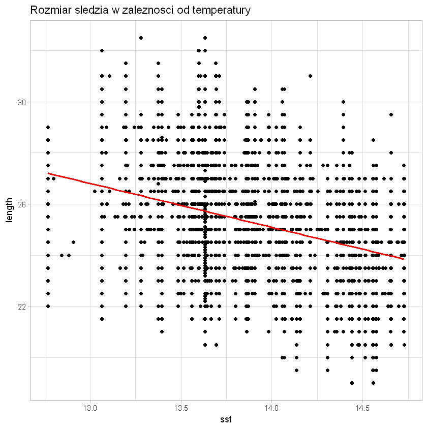

```r
ggplot(fish_data, aes(sst, length)) + geom_point() + geom_smooth(color="red", method="lm") +
theme_light() + ggtitle('Rozmiar śledzia w zależności od temperatury')
```

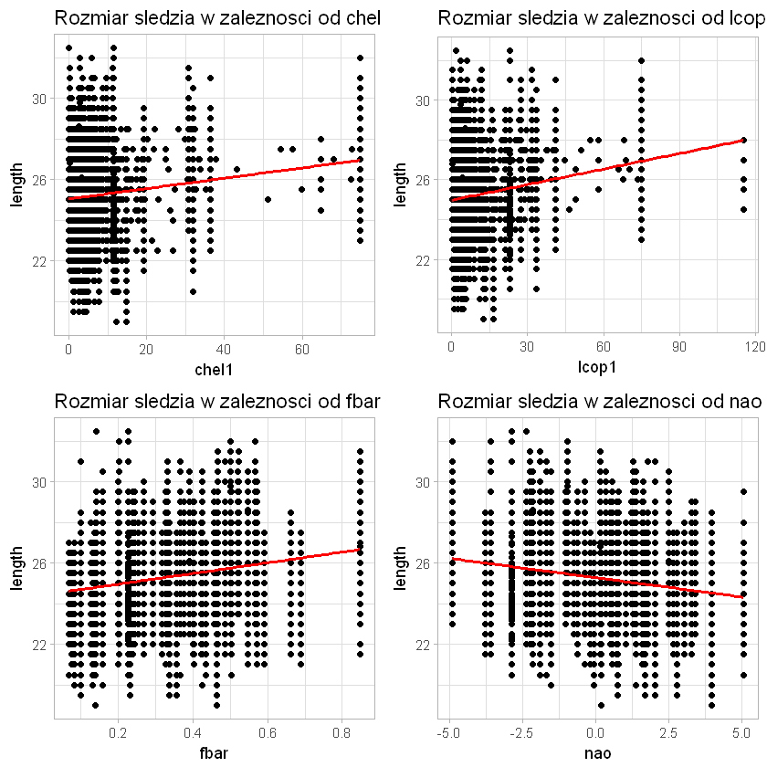

```r
c_2 <- ggplot(fish_data, aes(chel1, length)) + geom_point() + geom_smooth(color="red", method="lm") +
  theme_light() + ggtitle('Rozmiar śledzia w zależności od chel1')
c_3 <- ggplot(fish_data, aes(lcop1, length)) + geom_point() + geom_smooth(color="red", method="lm") +
  theme_light() + ggtitle('Rozmiar śledzia w zależności od lcop1')
c_4 <- ggplot(fish_data, aes(fbar, length)) + geom_point() + geom_smooth(color="red", method="lm") +
  theme_light() + ggtitle('Rozmiar śledzia w zależności od fbar')
c_5 <- ggplot(fish_data, aes(nao, length)) + geom_point() + geom_smooth(color="red", method="lm") +
  theme_light() + ggtitle('Rozmiar śledzia w zależności od nao')

grid.arrange(c_2,c_3,c_4,c_5, nrow=2)
```

```r
sample <- sample_n(fish_data, 1000)
q <- ggplot(sample, aes(lp, length)) +
  geom_jitter() +
  geom_smooth(se = FALSE, color="red", method = 'loess') +
  geom_vline(xintercept = 18000, colour="darkblue", size=1) +
  ggtitle('Zmiana długości śledzia') +
  theme_light()
ggplotly(q)
```

```
We recommend that you use the dev version of ggplot2 with `ggplotly()`
Install it with: `devtools::install_github('hadley/ggplot2')`
```

[interactive chart not shown]

## Model regresji

Podział zbioru danych

```r
set.seed(23)
inTraining <- createDataPartition(y = fish_data$length,p = .75,list = FALSE)

training <- fish_data[ inTraining,]
testing  <- fish_data[-inTraining,]
```

Schemat uczeniu modelu z wykorzystaniem powtórzonej oceny krzyżowej

```r
ctrl <- trainControl(method = "repeatedcv", number = 3,repeats = 6)
```

Uczenie modelu random forest

```r
set.seed(23)
fitrf <- train(length ~ .,data = training,method = "rf", trControl = ctrl, ntree = 10, importance=T)
fitrf
```

[output not shown]

Ocena ważności atrybutów RF

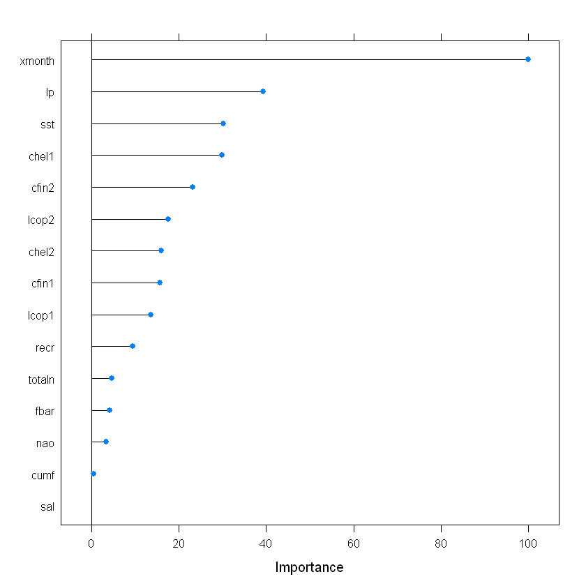

```r
plot(varImp(fitrf))
```

Testowanie modelu random forest

```r
rfLength <- predict(fitrf, newdata = testing)
postResample(pred = rfLength, obs = testing$length)
```

**RMSE**

1.09257720254321

**Rsquared**

0.567652197430898

Uczenie modelu regresji

```r
fit_reg <- train(length ~ ., data = fish_data, method = "lm", trControl = ctrl)
fit_reg
```

```
Linear Regression

52582 samples
   15 predictor

No pre-processing
Resampling: Cross-Validated (3 fold, repeated 6 times)
Summary of sample sizes: 35053, 35056, 35055, 35055, 35055, 35054, ...
Resampling results:

  RMSE      Rsquared
  1.328653  0.3538557

Tuning parameter 'intercept' was held constant at a value of TRUE
```

Ocena ważności atrybutów REG

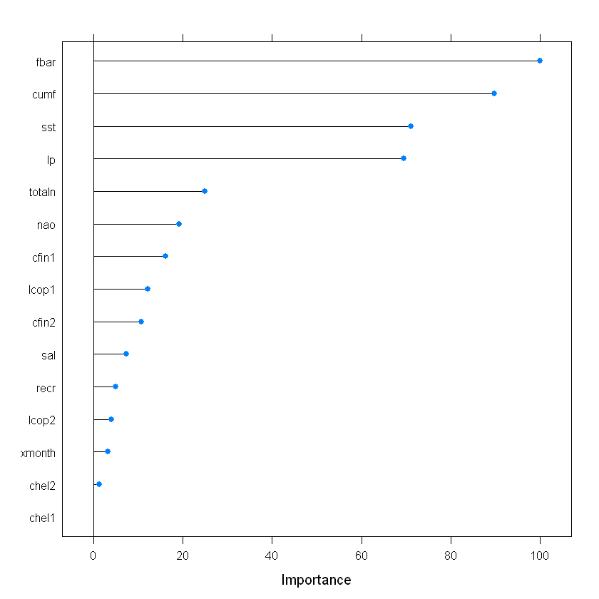

```r
plot(varImp(fit_reg))
```

Testowanie modelu regresji

```r
regLength <- predict(fit_reg, newdata = testing)
postResample(pred = regLength, obs = testing$length)
```

**RMSE**

1.33705081421562

**Rsquared**

0.349390480644091